# Figure6_python

```python
#supress warnings
import warnings
warnings.simplefilter(action='ignore', category=FutureWarning)
import sys
import os
_stderr = sys.stderr
null = open(os.devnull,'wb')
```

```python
import os
os.getcwd()
work_dir = 'res'
```

```python
import scanpy as sc
#set some figure parameters for nice display inside jupyternotebooks.
%matplotlib inline
sc.settings.set_figure_params(dpi=80, frameon=False, figsize=(5, 5), facecolor='white')

#make a directory for to store the processed scRNA-seq data.
if not os.path.exists(os.path.join(work_dir, 'scRNA')):
    os.makedirs(os.path.join(work_dir, 'scRNA'))
```

Read in the scRNA-seq count matrix into [AnnData](https://anndata.readthedocs.io/en/latest/) object.

```python
adata = sc.read_h5ad(os.path.join(work_dir, "scRNA/P7_rna_tumor.h5ad"))
adata
```

```
AnnData object with n_obs × n_vars = 6000 × 22099
    obs: 'orig.ident', 'nCount_RNA', 'nFeature_RNA', 'sample_fullname', 'batch', 'sample', 'PBN_sensitivity', 'patient', 'percent.mt', 'nCount_SCT', 'nFeature_SCT', 'S.Score', 'G2M.Score', 'Phase', 'SCT_snn_res.0.4', 'seurat_clusters', 'predicted.celltype.l1.score', 'predicted.celltype.l1', 'predict…
    var: 'features'
    obsm: 'X_integrated_dr', 'X_pca', 'X_umap'
    varm: 'PCs'
```

```python
adata.var_names_make_unique()
```

```python
adata.obs['seurat_clusters'] = adata.obs['seurat_clusters'].astype(str)
sc.pl.embedding(adata, color = 'seurat_clusters',basis='umap')
```

[output not shown]

```python
import os
import pycisTopic
import pandas as pd
#set some figure parameters for nice display inside jupyternotebooks.
%matplotlib inline

#make a directory for to store the processed scRNA-seq data.
if not os.path.exists(os.path.join(work_dir, 'scATAC')):
    os.makedirs(os.path.join(work_dir, 'scATAC'))
tmp_dir = '/Users/fyan1/'
```

## load scATAC-seq peak counts & Create cisTopic object

```python
# load peak count matrix
from pycisTopic.cistopic_class import *
count_matrix = pd.read_csv(os.path.join(work_dir, 'scATAC/p7_peak_counts_subsample.txt'), sep='\t')
count_matrix.head()
```

|  | P_S7_AAACGAACACTGATAC.1 | P_S7_AAACGAATCCACGAGC.1 | P_S7_AAACGAATCCCGAAGC.1 | P_S7_AAACGAATCGCTAGTA.1 | P_S7_AAACTCGCAGTAACGG.1 | P_S7_AAACTCGGTCTGCGCA.1 | P_S7_AAACTCGGTTGGCTAT.1 | P_S7_AAACTCGTCCAAGAGG.1 | P_S7_AAACTCGTCCTGAAAC.1 | P_S7_AAACTCGTCTTCTTCC.1 | ... | P_R7_TTTGGCCTCGTTCAGA.1 | P_R7_TTTGGCCTCTACTGCC.1 | P_R7_TTTGGTTAGAGAGTAG.1 | P_R7_TTTGGTTAGGGAAGCG.1 | P_R7_TTTGGTTGTCATAGAA.1 | P_R7_TTTGGTTGTGATAGAT.1 | P_R7_TTTGGTTTCTCCTTAA.1 | P_R7_TTTGGTTTCTGGCTAA.1 | P_R7_TTTGTGTTCAATCGTG.1 | P_R7_TTTGTGTTCACAACAC.1 |
| --- | --- | --- | --- | --- | --- | --- | --- | --- | --- | --- | --- | --- | --- | --- | --- | --- | --- | --- | --- | --- | --- |
| chr1:9776-10668 | 0 | 0 | 0 | 0 | 0 | 0 | 0 | 0 | 0 | 0 | ... | 0 | 0 | 0 | 0 | 0 | 0 | 0 | 0 | 0 | 0 |
| chr1:180622-181573 | 0 | 0 | 0 | 0 | 0 | 0 | 0 | 0 | 0 | 0 | ... | 0 | 0 | 0 | 0 | 0 | 0 | 0 | 0 | 0 | 0 |
| chr1:267558-268466 | 0 | 0 | 0 | 0 | 0 | 0 | 0 | 0 | 0 | 0 | ... | 0 | 0 | 0 | 0 | 0 | 0 | 0 | 0 | 0 | 0 |
| chr1:585750-586648 | 0 | 0 | 0 | 0 | 0 | 0 | 0 | 0 | 0 | 0 | ... | 0 | 0 | 0 | 0 | 0 | 0 | 0 | 0 | 0 | 0 |
| chr1:629483-630392 | 0 | 0 | 0 | 0 | 0 | 1 | 0 | 1 | 1 | 1 | ... | 0 | 0 | 0 | 0 | 0 | 0 | 0 | 0 | 0 | 0 |

5 rows × 6000 columns

```python
count_matrix.shape
```

```
(159290, 6000)
```

```python
# load metadata
atac_meta = pd.read_csv(os.path.join(work_dir, 'scATAC/p7_atac_meta.txt'), sep='\t')
atac_meta['sample_id'] = 'p7'
atac_meta['PBN_sensitivity'] = atac_meta['PBN_sensitivity'].astype(str)
atac_meta = atac_meta.rename(index=lambda x: x.replace('-', '.'))
atac_meta.head()
```

|  | orig.ident | nCount_ATAC | nFeature_ATAC | total | duplicate | chimeric | unmapped | lowmapq | mitochondrial | nonprimary | ... | prediction.score.Treg | prediction.score.CD8.TCM | prediction.score.gdT | prediction.score.pDC | prediction.score.CD4.Naive | prediction.score.CD4.Proliferating | prediction.score.MAIT | prediction.score.max | PBN_sensitivity | sample_id |
| --- | --- | --- | --- | --- | --- | --- | --- | --- | --- | --- | --- | --- | --- | --- | --- | --- | --- | --- | --- | --- | --- |
| P_S7_AAACGAACACTGATAC.1 | SeuratProject | 17836 | 13365 | 51636 | 14008 | 22 | 572 | 4930 | 5510 | 3 | ... | 0.0 | 0 | 0 | 0.0 | 0 | 0.0 | 0 | 0.627708 | S | p7 |
| P_S7_AAACGAATCCACGAGC.1 | SeuratProject | 13741 | 11193 | 33955 | 7746 | 11 | 296 | 2776 | 2853 | 4 | ... | 0.0 | 0 | 0 | 0.0 | 0 | 0.0 | 0 | 0.868813 | S | p7 |
| P_S7_AAACGAATCCCGAAGC.1 | SeuratProject | 20859 | 15002 | 55675 | 17081 | 15 | 654 | 4331 | 3994 | 2 | ... | 0.0 | 0 | 0 | 0.0 | 0 | 0.0 | 0 | 0.967246 | S | p7 |
| P_S7_AAACGAATCGCTAGTA.1 | SeuratProject | 22007 | 16312 | 55583 | 18228 | 7 | 631 | 3513 | 827 | 6 | ... | 0.0 | 0 | 0 | 0.0 | 0 | 0.0 | 0 | 0.888698 | S | p7 |
| P_S7_AAACTCGCAGTAACGG.1 | SeuratProject | 16598 | 12834 | 47984 | 12599 | 39 | 586 | 4481 | 5613 | 2 | ... | 0.0 | 0 | 0 | 0.0 | 0 | 0.0 | 0 | 0.919230 | S | p7 |

5 rows × 64 columns

```python
# check the length of intersected barcodes
len(count_matrix.columns.intersection(atac_meta.index))
```

```
6000
```

```python
# create cistopic object
path_to_blacklist='/Users/fyan1/pycisTopic/blacklist/hg38-blacklist.v2.bed'
cistopic_obj = create_cistopic_object(fragment_matrix=count_matrix,
                                      path_to_blacklist=path_to_blacklist)
```

```
2024-06-26 14:59:27,222 cisTopic     INFO     Converting fragment matrix to sparse matrix
2024-06-26 14:59:34,630 cisTopic     INFO     Removing blacklisted regions
2024-06-26 14:59:35,008 cisTopic     INFO     Creating CistopicObject
2024-06-26 14:59:35,886 cisTopic     INFO     Done!
```

```python
print(cistopic_obj)
```

```
CistopicObject from project cisTopic with n_cells × n_regions = 6000 × 158011
```

```python
# Adding cell information
cistopic_obj.add_cell_data(atac_meta)
```

```
Columns ['sample_id'] will be overwritten
```

```python
cistopic_obj.cell_data.head()
```

|  | cisTopic_nr_acc | cisTopic_log_nr_frag | cisTopic_nr_frag | cisTopic_log_nr_acc | orig.ident | nCount_ATAC | nFeature_ATAC | total | duplicate | chimeric | ... | prediction.score.Treg | prediction.score.CD8.TCM | prediction.score.gdT | prediction.score.pDC | prediction.score.CD4.Naive | prediction.score.CD4.Proliferating | prediction.score.MAIT | prediction.score.max | PBN_sensitivity | sample_id |
| --- | --- | --- | --- | --- | --- | --- | --- | --- | --- | --- | --- | --- | --- | --- | --- | --- | --- | --- | --- | --- | --- |
| P_S7_AAACGAACACTGATAC.1___cisTopic | 13247 | 4.247089 | 17664 | 4.122118 | SeuratProject | 17836 | 13365 | 51636 | 14008 | 22 | ... | 0.0 | 0 | 0 | 0.0 | 0 | 0.0 | 0 | 0.627708 | S | p7 |
| P_S7_AAACGAATCCACGAGC.1___cisTopic | 11108 | 4.134591 | 13633 | 4.045636 | SeuratProject | 13741 | 11193 | 33955 | 7746 | 11 | ... | 0.0 | 0 | 0 | 0.0 | 0 | 0.0 | 0 | 0.868813 | S | p7 |
| P_S7_AAACGAATCCCGAAGC.1___cisTopic | 14887 | 4.315928 | 20698 | 4.172807 | SeuratProject | 20859 | 15002 | 55675 | 17081 | 15 | ... | 0.0 | 0 | 0 | 0.0 | 0 | 0.0 | 0 | 0.967246 | S | p7 |
| P_S7_AAACGAATCGCTAGTA.1___cisTopic | 16190 | 4.339372 | 21846 | 4.209247 | SeuratProject | 22007 | 16312 | 55583 | 18228 | 7 | ... | 0.0 | 0 | 0 | 0.0 | 0 | 0.0 | 0 | 0.888698 | S | p7 |
| P_S7_AAACTCGCAGTAACGG.1___cisTopic | 12720 | 4.215955 | 16442 | 4.104487 | SeuratProject | 16598 | 12834 | 47984 | 12599 | 39 | ... | 0.0 | 0 | 0 | 0.0 | 0 | 0.0 | 0 | 0.919230 | S | p7 |

5 rows × 68 columns

```python
pickle.dump(cistopic_obj,
            open(os.path.join(work_dir, 'scATAC/cistopic_obj.pkl'), 'wb'))
```

```python
import pickle
cistopic_obj = pickle.load(open(os.path.join(work_dir, 'scATAC/cistopic_obj.pkl'), 'rb'))
from pycisTopic.cistopic_class import *
models=run_cgs_models(cistopic_obj,
                    n_topics=[2,4,10,16,32,48],
                    n_cpu=8,
                    n_iter=500,
                    random_state=555,
                    alpha=50,
                    alpha_by_topic=True,
                    eta=0.1,
                    eta_by_topic=False,
                    save_path=None,
                    _temp_dir = os.path.join(tmp_dir + 'ray_spill'))
```

[output not shown]

```python
# save results
if not os.path.exists(os.path.join(work_dir, 'scATAC/models')):
    os.makedirs(os.path.join(work_dir, 'scATAC/models'))

pickle.dump(models,
            open(os.path.join(work_dir, 'scATAC/models/multiome_models_500_iter_LDA.pkl'), 'wb'))
```

### Analyze models

#### We will make use of four quality metrics to select the model with the optimal amount of topics:

1. [Arun *et al.* 2010](http://link.springer.com/10.1007/978-3-642-13657-3_43) (The better the model, the lower the metric.)
2. [Cao & Juan *et al.* 2009](https://linkinghub.elsevier.com/retrieve/pii/S092523120800372X) (The better the model, the lower the metric.)
3. [Mimno *et al.* 2011](http://dirichlet.net/pdf/mimno11optimizing.pdf) (The better the model, the higher coherence.)
4. Log likelihood (The better the model, the higher the log-likelihood.)

For more information on these metrics see publications (linked above) and the [read the docs](https://pycistopic.readthedocs.io/en/latest/) page of pycisTopic.

[figure not shown]

```python
import pickle
import os
work_dir = 'P7_res'
from pycisTopic.cistopic_class import *
models = pickle.load(open(os.path.join(work_dir, 'scATAC/models/multiome_models_500_iter_LDA.pkl'), 'rb'))
cistopic_obj = pickle.load(open(os.path.join(work_dir, 'scATAC/cistopic_obj.pkl'), 'rb'))
from pycisTopic.lda_models import *
model = evaluate_models(models,
                       select_model=16, # select optimal topic number
                       return_model=True,
                       metrics=['Arun_2010','Cao_Juan_2009', 'Minmo_2011', 'loglikelihood'],
                       plot_metrics=False)
```

The metrics seem to stabelise with a model using 16 topics, so let's choose that model.

```python
cistopic_obj.add_LDA_model(model)
pickle.dump(cistopic_obj,
            open(os.path.join(work_dir, 'scATAC/cistopic_obj.pkl'), 'wb'))
```

### Inferring candidate enhancer regions

Next we will infer candidate enhancer regions by:

1. binarization of region-topic probabilites.
2. calculation differentially accessibile regions (DARs) per cell type.

These regions will be used as input for the next step, [pycistarget](https://pycistarget.readthedocs.io/en/latest/), in which we will look which motifs are enriched in these regions.

First we will binarize the topics using the [otsu](http://ieeexplore.ieee.org/document/4310076/) method and by taking the top 3k regions per topic.

```python
from pycisTopic.topic_binarization import *
region_bin_topics_otsu = binarize_topics(cistopic_obj, method='otsu')
region_bin_topics_top3k = binarize_topics(cistopic_obj, method='ntop', ntop = 3000)
```

```python
#!/Users/fyan1/miniconda3/envs/scenicplus/bin/pip install numba==0.57.0
# numba.__version__
```

```python
import pycisTopic
pycisTopic.__version__
```

```
'1.0.3.dev17+g0b5f4d1'
```

```python
from pycisTopic.diff_features import *
imputed_acc_obj = impute_accessibility(cistopic_obj, selected_cells=None,
                                       selected_regions=None, scale_factor=10**6)
normalized_imputed_acc_obj = normalize_scores(imputed_acc_obj, scale_factor=10**4)
variable_regions = find_highly_variable_features(normalized_imputed_acc_obj, plot = False)
markers_dict = find_diff_features(cistopic_obj, imputed_acc_obj, variable='sample',
                                  var_features=variable_regions, split_pattern = '-')
```

```python
print("Number of DARs found:")
print("---------------------")
for x in markers_dict:
    print(f"  {x}: {len(markers_dict[x])}")
```

```
Number of DARs found:
---------------------
  P_R7: 16151
  P_S7: 5450
```

```python
# Save results
if not os.path.exists(os.path.join(work_dir, 'scATAC/candidate_enhancers')):
    os.makedirs(os.path.join(work_dir, 'scATAC/candidate_enhancers'))
import pickle
pickle.dump(region_bin_topics_otsu, open(os.path.join(work_dir, 'scATAC/candidate_enhancers/region_bin_topics_otsu.pkl'), 'wb'))
pickle.dump(region_bin_topics_top3k, open(os.path.join(work_dir, 'scATAC/candidate_enhancers/region_bin_topics_top3k.pkl'), 'wb'))
pickle.dump(markers_dict, open(os.path.join(work_dir, 'scATAC/candidate_enhancers/markers_dict.pkl'), 'wb'))
```

```python
from pycisTopic.clust_vis import *
run_umap(cistopic_obj,
                 target  = 'cell', scale=False)
```

```
2024-06-26 17:46:02,360 cisTopic     INFO     Running UMAP
```

```python
plot_topic(cistopic_obj, reduction_name = 'UMAP',num_columns=4)
```

[output not shown]

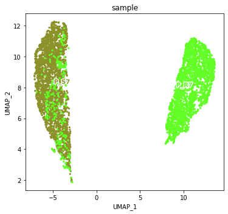

```python
plot_metadata(cistopic_obj,
                 reduction_name='UMAP',
                 variables=['sample'],
                 target='cell', num_columns=2,
                 text_size=10,
                 dot_size=5,
              #save= 'P8_atac_umap.pdf',
                 figsize=(10,5))
```

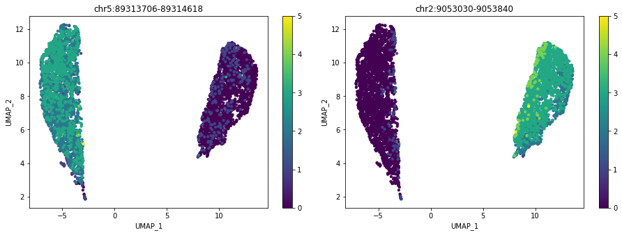

```python
from pycisTopic.clust_vis import plot_imputed_features
plot_imputed_features(
    cistopic_obj,
    reduction_name='UMAP',
    imputed_data=imputed_acc_obj,
    features=[markers_dict[x].index.tolist()[0] for x in ['P_S7', 'P_R7']],
    scale=False,
    num_columns=4
)
```